# Assignment 9

Yerin Jung

7/21/2018

# 1 Data

```r
ccard <-read_csv("creditcard.csv")
```

## 1.1 Quick EDA

First, I looked at the summary statistics of credit card data and found two points to adjust.  
1. `Class` variable should be a factor rather than an integer. As such, I changed it to a factor.  
2. `Time` variable is not necessarily needed for this modeling. As such, I removed the entire column.

```r
summary(ccard)
```

```
##       Time              V1                  V2
##  Min.   :     0   Min.   :-56.40751   Min.   :-72.71573
##  1st Qu.: 54201   1st Qu.: -0.92037   1st Qu.: -0.59855
##  Median : 84692   Median :  0.01811   Median :  0.06549
##  Mean   : 94814   Mean   :  0.00000   Mean   :  0.00000
##  3rd Qu.:139321   3rd Qu.:  1.31564   3rd Qu.:  0.80372
##  Max.   :172792   Max.   :  2.45493   Max.   : 22.05773
##  NA's   :1
##        V3                 V4                 V5
##  Min.   :-48.3256   Min.   :-5.68317   Min.   :-113.74331
##  1st Qu.: -0.8904   1st Qu.:-0.84864   1st Qu.:  -0.69160
##  Median :  0.1799   Median :-0.01985   Median :  -0.05434
##  Mean   :  0.0000   Mean   : 0.00000   Mean   :   0.00000
##  3rd Qu.:  1.0272   3rd Qu.: 0.74334   3rd Qu.:   0.61193
##  Max.   :  9.3826   Max.   :16.87534   Max.   :  34.80167
##
##        V6                 V7                 V8
##  Min.   :-26.1605   Min.   :-43.5572   Min.   :-73.21672
##  1st Qu.: -0.7683   1st Qu.: -0.5541   1st Qu.: -0.20863
##  Median : -0.2742   Median :  0.0401   Median :  0.02236
##  Mean   :  0.0000   Mean   :  0.0000   Mean   :  0.00000
##  3rd Qu.:  0.3986   3rd Qu.:  0.5704   3rd Qu.:  0.32735
##  Max.   : 73.3016   Max.   :120.5895   Max.   : 20.00721
##
##        V9                 V10                 V11
##  Min.   :-13.43407   Min.   :-24.58826   Min.   :-4.79747
##  1st Qu.: -0.64310   1st Qu.: -0.53543   1st Qu.:-0.76249
##  Median : -0.05143   Median : -0.09292   Median :-0.03276
##  Mean   :  0.00000   Mean   :  0.00000   Mean   : 0.00000
##  3rd Qu.:  0.59714   3rd Qu.:  0.45392   3rd Qu.: 0.73959
##  Max.   : 15.59500   Max.   : 23.74514   Max.   :12.01891
##
##       V12                V13                V14
##  Min.   :-18.6837   Min.   :-5.79188   Min.   :-19.2143
##  1st Qu.: -0.4056   1st Qu.:-0.64854   1st Qu.: -0.4256
##  Median :  0.1400   Median :-0.01357   Median :  0.0506
##  Mean   :  0.0000   Mean   : 0.00000   Mean   :  0.0000
##  3rd Qu.:  0.6182   3rd Qu.: 0.66251   3rd Qu.:  0.4931
##  Max.   :  7.8484   Max.   : 7.12688   Max.   : 10.5268
##
```

[output cut: 33 more lines]

```
##  Min.   :-22.565679   Min.   :-15.43008   Min.   :    0.00
##  1st Qu.: -0.070840   1st Qu.: -0.05296   1st Qu.:    5.60
##  Median :  0.001342   Median :  0.01124   Median :   22.00
##  Mean   :  0.000000   Mean   :  0.00000   Mean   :   88.35
##  3rd Qu.:  0.091045   3rd Qu.:  0.07828   3rd Qu.:   77.17
##  Max.   : 31.612198   Max.   : 33.84781   Max.   :25691.16
##
##      Class
##  Min.   :0.000000
##  1st Qu.:0.000000
##  Median :0.000000
##  Mean   :0.001728
##  3rd Qu.:0.000000
##  Max.   :1.000000
##
```

```r
ccard$Class <-as.factor(ccard$Class)
ccard <- ccard[,c(2:31)]
```

I checked the number of NA, just in case we might have one.

```r
sum(is.na(ccard))
```

```
## [1] 0
```

## 1.2 Down-Sampling

As we can see from the below table, we have an extremely unbalanced data.  
When we look at a table of `Class` variable, fraud class($1$) take only $0.173$%.

Since the minority case ($1$ case in this case) takes less than $1$%, it is highly likely for our future model to not detect these cases.  
For instance, even if we predict all of the cases as `non-fraud`, we will still be able to get more than $99$% accuracy.

Therefore,  
1. We need to do down-sampling to balance the imbalanced dataset.  
2. We need to come up with the right evaluation metrics later on.

```r
table(ccard$Class)
```

```
##
##      0      1
## 284315    492
```

Since the $1$ class has around $492$ observations, I sampled $5000$ cases from `Class == 0`.

```r
set.seed(101)
ccard_0case <- ccard %>% filter(Class=='0')

df2 <-ccard_0case[sample(nrow(ccard_0case), 5000), ]
df<-rbind(df2,ccard[ccard$Class=='1',])

table(df$Class)
```

```
##
##    0    1
## 5000  492
```

# 2 Random Forest

Even though a single decision tree has an advantage of interpretation, and easy to fit into the model, it has a huge disadvantage of less **accuracy**.

Random Forests combine the simplicity of decision trees with flexibility resulting in a great improvement in **accuracy**.  
In a random forest, we follow the following steps.

1. Bootstrap the given dataset.
2. Create a decision tree using the bootstrapped dataset, but only use a random subset of variables at each step(node split).
3. Repeat step 1 and 2.

The variety in the steps is what makes a random forest more effective than individual decision trees. [(source)](https://www.youtube.com/watch?v=J4Wdy0Wc_xQ)

## 2.1 Modeling

```r
h2o.init(nthreads=-1, max_mem_size='4G')
```

After initializing the h2o,  
1. I changed the dataset into h2o data frame format,  
2. split the dataset into `train`, `valid`, and `test` set, and  
3. set the response and predictive variables respectively.

```r
df.hex <-as.h2o(df)

splits <- h2o.splitFrame(
  data = df.hex,
  ratios = c(0.3,0.3),
    destination_frames = c("train", "valid", "test"), seed = 101
)
train <- splits[[1]]
valid <- splits[[2]]
test  <- splits[[3]]

resp <- 'Class'
pred <- setdiff(names(df), resp)
```

Then, I built a random forest model, using `h2o.randomForest`.  
Each hyper-parameter represents as follows. [(source)](https://www.kaggle.com/mlandry/random-forest-example)

1. `ntrees`: It determines the number of trees to grow.
2. `max_depth`: It determines the maximum depth to grow the tree. The bigger, the smaller number of classes will be assigned in the leaf nodes.
3. `mtries`: It selects the number of variables that would be sampled as candidate at each node split.
4. `min_rows`: It determines the number of rows to assign to terminal nodes.

```r
rf_model <- h2o.randomForest(
      training_frame = train,
      validation_frame = valid,
      x=pred,
      y=resp,
      model_id = "rf_model",
      ntrees = 100,
      max_depth = 30,
      mtries = 4,
      min_rows = 4,
      stopping_rounds = 2,
      stopping_tolerance = 1e-2,
      score_each_iteration = T,
      seed=101
      )
```

After fitting the model, I looked at the performance metrics as follows.

1. `MSE`: Means Squared Error is the average of the squares of the errors.

$$MSE=\frac{1}{n}\sum\limits_{i=1}^{n}{(Y_{i}-\hat{Y_{i}})^{2}}$$
2. `RMSE`: Root Mean Squared Error is a square root version of `MSE`. The power of ‘square root’ empowers this metric to show large number deviations.

$$RMSE=\sqrt{\frac{\sum\limits_{i=1}^{n}{(Y_{i}-\hat{Y_{i}})^{2}}}{N}}$$

3. `LogLoss`: Log Loss quantifies the accuracy of a classifier by penalizing false classifications. [(source)](https://datawookie.netlify.com/blog/2015/12/making-sense-of-logarithmic-loss/) The formula can be defined as follows.

$$- \frac{1}{N} \sum_{i=1}^N [y_{i} \log \, p_{i} + (1 - y_{i}) \log \, (1 - p_{i})].$$

4. `AUC`: `ROC` curve is defined by between sensitivity and 1-specificity (false positive rate), and `AUC` is the area under this `ROC` curve.
5. `Gini`: Gini is a ratio between (1) the area between the ROC curve and the diagonal line & (2) the area of the above triangle. The formula would be

$$Gini = 2*AUC - 1$$

```r
## Get the AUC on the validation set
rf_perform <- h2o.performance(rf_model,test)
print( sprintf("MSE: %s, RMSE: %s, LogLoss: %s, AUC: %s, Gini: %s",
               round(rf_perform@metrics$MSE,5),
               round(rf_perform@metrics$RMSE, 5),
               round(rf_perform@metrics$logloss,5),
               round(rf_perform@metrics$AUC,5),
               round(rf_perform@metrics$Gini,5))
       )
```

```
## [1] "MSE: 0.01495, RMSE: 0.12226, LogLoss: 0.11745, AUC: 0.97653, Gini: 0.95305"
```

## 2.2 Grid-Search

To find the best combination of hyper-parameters, I am going to conduct grid-search.  
For this assignment, I tried different ranges from three parameters: `ntrees`, `max_depth`, and `mtries`.

```r
hyper_params = list( ntrees = seq(100,1000,200),
                     max_depth=seq(10,30,5),
                     mtries =seq(4,20,4))

grid <- h2o.grid(
  hyper_params = hyper_params,

  search_criteria = list(strategy = "Cartesian"),

  algorithm="randomForest",

  grid_id="rf_grid",

  x = pred,
  y = resp,
  training_frame = train,
  validation_frame = valid,
  seed = 101,
  stopping_rounds = 5,
  stopping_tolerance = 1e-8,
  stopping_metric = "AUC",
  score_tree_interval = 10
)
```

After doing the grid search, I sorted the model by descending order of AUC, to find the best model to use.

```r
## sort the grid models by decreasing AUC
sortedGrid <- h2o.getGrid("rf_grid", sort_by="auc", decreasing = TRUE)
print(sortedGrid)
```

```
## H2O Grid Details
## ================
##
## Grid ID: rf_grid
## Used hyper parameters:
##   -  max_depth
##   -  mtries
##   -  ntrees
## Number of models: 125
## Number of failed models: 0
##
## Hyper-Parameter Search Summary: ordered by decreasing auc
##   max_depth mtries ntrees         model_ids                auc
## 1        10     12    500  rf_grid_model_60 0.9682400429774712
## 2        10     12    900 rf_grid_model_110 0.9682400429774712
## 3        10     12    300  rf_grid_model_35 0.9682400429774712
## 4        10     12    700  rf_grid_model_85 0.9682400429774712
## 5        10     12    100  rf_grid_model_10 0.9679196833861516
##
## ---
##     max_depth mtries ntrees         model_ids                auc
## 120        20      4    700  rf_grid_model_77 0.9518844536883245
## 121        20      4    900 rf_grid_model_102 0.9518844536883245
## 122        25     20    100  rf_grid_model_23  0.950391085131865
## 123        30     20    100  rf_grid_model_24  0.950391085131865
## 124        20     20    100  rf_grid_model_22  0.950391085131865
## 125        15     20    100  rf_grid_model_21 0.9499277958767256
```

## 2.3 Best Model

I set the best model as the one with the highest AUC from the grid-search result.  
I printed the variable importances, the number of trees, and the maximum depth of the tree, used in my best model.

```r
best_model <- h2o.getModel(sortedGrid@model_ids[[1]])
top_5<-best_model@model$variable_importances$variable[1:5]
print( sprintf("The top 5 important variables: %s",paste(top_5,collapse=" ")))
```

```
## [1] "The top 5 important variables: V14 V17 V10 V12 V11"
```

```r
ntrees <- best_model@model$model_summary$number_of_trees
max_depth <- best_model@model$model_summary$max_depth
print( sprintf("In my best model, the number of trees is %s, and maximum depth of the tree is %s", ntrees, max_depth) )
```

```
## [1] "In my best model, the number of trees is 160, and maximum depth of the tree is 10"
```

In addition, I plotted `Training RMSE` and `Validation RMSE` along with the number of trees as follows.

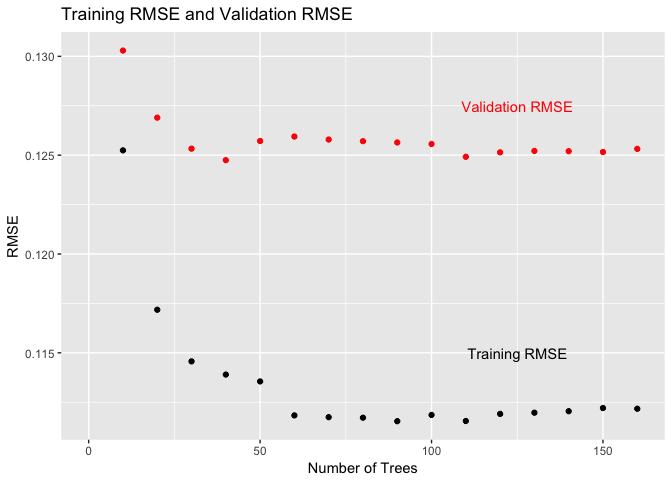

```r
scoring_history <- as.data.frame(best_model@model$scoring_history)

ggplot(scoring_history, aes(x=number_of_trees))+
  geom_point(aes(y=training_rmse), color="black")+
  geom_point(aes(y=validation_rmse), color="red")+
  ylab("RMSE")+
  xlab("Number of Trees")+
  annotate("text", x=125, y=0.1275, label="Validation RMSE", color="red")+
  annotate("text", x=125, y=0.115, label="Training RMSE", color="black")+
  ggtitle("Training RMSE and Validation RMSE")
```

As we can see from the above plot,  
1. Validation RMSE is obviously higher than training RMSE, and  
2. As we increase the number of trees, both RMSE started to dramatically decrease, and then they became pretty much stable no matter how we drastically increased the number of trees.

Finally, I tested on my `test` data to compare with the first random forest result, which I selected random hyperparameters.

```r
my.perf = h2o.performance(best_model, test)

print( sprintf("MSE: %s, RMSE: %s, LogLoss: %s, AUC: %s, Gini: %s",
               round(my.perf@metrics$MSE,5),
               round(my.perf@metrics$RMSE, 5),
               round(my.perf@metrics$logloss,5),
               round(my.perf@metrics$AUC,5),
               round(my.perf@metrics$Gini,5))
       )
```

```
## [1] "MSE: 0.01382, RMSE: 0.11757, LogLoss: 0.06202, AUC: 0.97808, Gini: 0.95616"
```

As we can see from the above result, we can find that overall results are improved.  
(For instance, `AUC` is improved from around 97% to 98%.)

To conclude, I plotted both `ROC` and `Precision-Recall` curve.

```r
tpr=as.data.frame(h2o.tpr(my.perf))
fpr=as.data.frame(h2o.fpr(my.perf))
ROC_out<-merge(tpr,fpr,by='threshold')


precision=as.data.frame(h2o.precision(my.perf))
recall=as.data.frame(h2o.recall(my.perf))
PR_out<-merge(precision,recall,by='threshold')
```

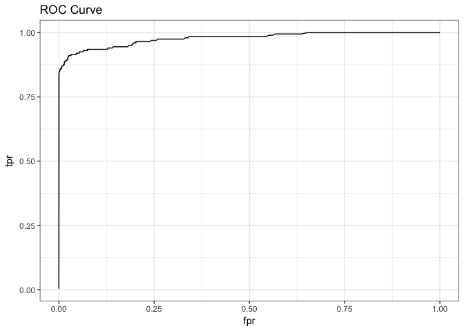

```r
ggplot(ROC_out, aes(x = fpr, y = tpr)) +
  theme_bw() +
  geom_line() +
  ggtitle("ROC Curve")
```

1. `ROC`: As we can see from the above plot, it is pretty much close to the top-left corner (Our AUC is around 0.98).

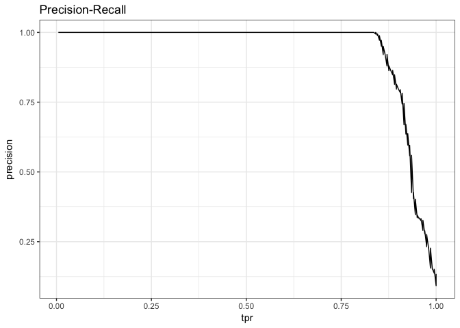

```r
ggplot(PR_out, aes(x = tpr, y = precision)) +
  theme_bw() +
  geom_line() +
  ggtitle("Precision-Recall")
```

2. `Precision-Recall`: I believe that since we have a quite imbalanced dataset, we better to look at the precision-recall curve since precision is directly influenced by class imbalance. Still, we can find that the graph is pretty much close to the upper-right corner, which is our optimum.

```r
h2o.shutdown(prompt=FALSE)
```

```
## [1] TRUE
```